# Final assessment Pedro

Pedro de Bos

09/04/2022

**Description of assignment**

For many brain-related neuronal diseases, it is necessary to study neurons to properly treat the disease. However, with current technology it’s practically impossible to extract neurons from the brain. Instead, fibroblasts of the patient are differentiated to induced pluripotent stem cells (iPSC), which are then differentiated into neuronal tissue. This differentiation from fibrolbasts to iPSC’s can take up to 2 months. If it was possible to skip this step, and immediately go from fibroblasts to neuronal cells, treatment of neuronal diseases could be significantly improved.

The subject of this analysis is the differentiation of fibroblasts in two different conditions:

1: Fibroblasts exposed to control transcription factor BCLXL. The anti-apoptotic gene BCLXL is known to reduce cell death during neuronal reprogramming of cells.

2: Fibroblasts exposed to the experimental transcription factor ONECUT2, a gene which is expected to stimulate the neuronal reprogramming of cells.

A paired-end stranded protocol RNA-seq has been performed for the analysis of these fibroblasts (strain CL150003), in duplo for both BCLXL and ONECUT. The research question for this experiment is:

**What are the differences in gene expression between BCLXL exposed and ONECUT exposed fibroblasts?**

To analyse the quality of the FASTQ-files, a FASTQC-analysis has been perormed on these files, for both forward and reverse reads. In these FASTQC analysis’, the PerBaseQuality and PerSequenceQuality were inspected. Due to practical limitations, only the highest quality and lowest quality figures are shown:

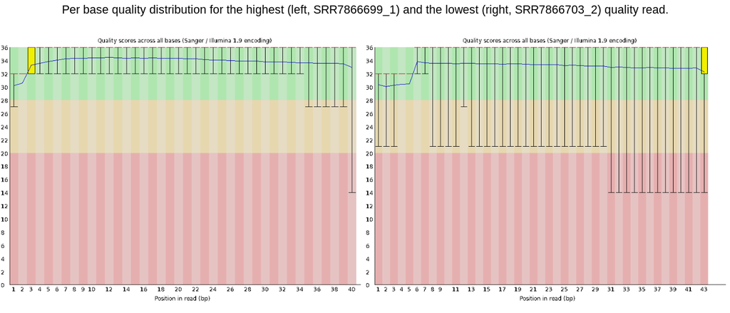

Figure 1: Per base quality score of the highest quality read (left, SRR7866699_1) and the lowest quality (right, SRR7866703_2) read, based on the phred-scale (0-40). A average quality score of >30 is seen as sufficient.

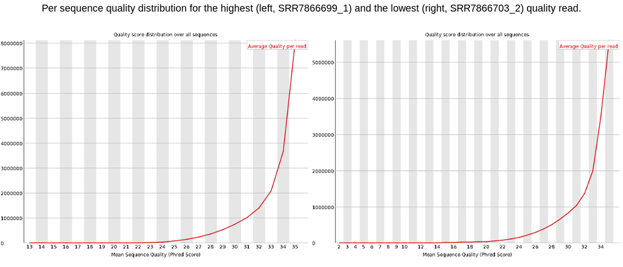

Figure 2: Per sequence quality-score of the highest quality read (left, SRR7866699_1) and the lowest quality read (right, SRR7866703_2), based on the phred-scale (0-40). A average quality score of >30 is seen as sufficient.

Both graphs from figure 1 show a high average base read, with the blue line constantly staying at >30. Furthermore, both graphs show a exponential curve in their perSequenceQuality in figure 2, which implies the average read quality is high. Due to this, we can conclude that the fastq data is of high enough quality to use.

To be able to properly study the data, a count-table has been generated based on the .bam files

```r
#Creating the required components of the count table
bam_dir<-"/home/daur2/rnaseq/rnaseq_onecut/bam/"
counts_dir<-"~/temp_daur2/eindopdracht/counts/"
bam_dir_regex<-regex(pattern="SRR7866[67][09][0349].bam$")
list.files(bam_dir, pattern = bam_dir_regex, full.names=TRUE)

#Command for the count table
read_counts<-featureCounts(
  files=bam_files,
  annot.inbuilt = "hg38",
  useMetaFeatures = TRUE,
  strandSpecific = 1,
  isPairedEnd = TRUE,
  nthreads = 4
)
```

However, for this study, the count tables were already pre-generated, thus they have instead been read in directly from the .rds files

```r
#Reading the count directory (was already pre-generated, otherwise would be from counts_dir)
read_counts<-readRDS("/home/daur2/rnaseq/rnaseq_onecut/counts/read_counts_OC2.rds")

#Control to see if this is the proper RDS file
read_counts$targets
```

```
## [1] "SRR7866699.bam" "SRR7866700.bam" "SRR7866703.bam" "SRR7866704.bam"
```

Now, using the data from the count tables and the data from a given file containing metadata, a DESeq2 object wil be created to use for further downstream analysises

```r
#Extracting the count matrix
count_matrix<-read_counts$counts

#Loading in metadata
metadata<-read_csv("/home/daur2/rnaseq/rnaseq_onecut/onecut_sampledata_OC2.csv") %>% as.data.frame()

#Transforming the row-names so metadata can properly combine with the count matrix
rownames(metadata)<-paste0(metadata$Run, ".bam")

#Checking if the names are truly the same
colnames(count_matrix)==rownames(metadata)
```

```
## [1] TRUE TRUE TRUE TRUE
```

```r
#Creating a factor-value in metadata, to be used to distinguish the monsters in graphs
metadata<-metadata %>% mutate(Treatment=c("Bclxl", "Bclxl", "OC2", "OC2"))
metadata$Treatment<-metadata$Treatment %>% factor(levels=c("Bclxl", "OC2"))

#Making sure treatment is a proper factor
is.factor(metadata$Treatment)
```

```
## [1] TRUE
```

```r
#Creating the DESeq2 object
dds<-DESeqDataSetFromMatrix(
  countData = count_matrix,
  colData = metadata,
  design = ~ Treatment
)
```

**Downstream analysis**

First off, a PCA analysis will be done to inspect any themes in relation between the measured monsters. For this, a normalised version of the dataset will be used, created using the rlog() command. For this PCA analysis, a bar-chart visualising the proportion of variance of each principal component and a PCA-graph will be created.

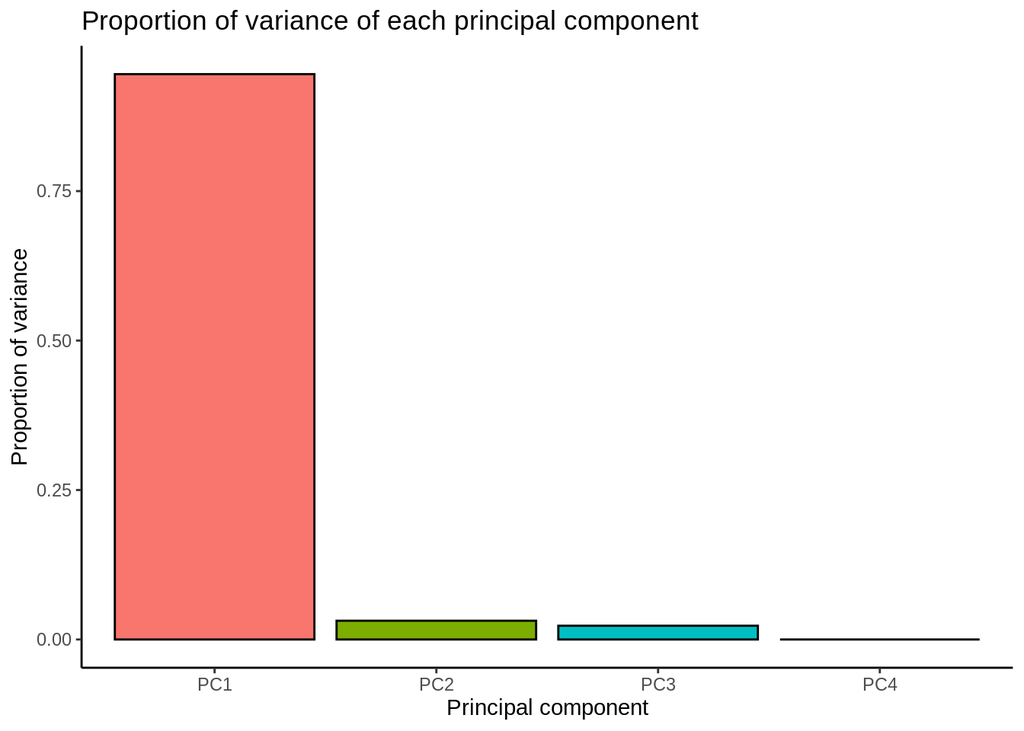

Figure 3: Bar graph of the proportion of variance explained by each of the 4 principal components. Based on normalised PCA data comparing the effect of bclxl (control) and OC2 on fibroblasts.

```r
#Normalising of DESeq2 library
dds_normalised<-rlog(dds)

#Creating a PCA (Assay transforms the dds into a single vector-like object, T creates a transposure, )
PCA<-dds_normalised %>% assay() %>% t() %>% prcomp()

#Creating a summary of the PCA
PCA_summary<-summary(PCA)$importance
PCA_summary_variance<-PCA_summary %>% t() %>% as.data.frame() %>% mutate(PC=colnames(PCA_summary))

#Creating a bar chart to summarise the proportions of variance
PCA_summary_variance %>% ggplot(aes(x=PC, y=`Proportion of Variance`, fill=PC))+
  geom_col(colour="black")+
  labs(
    title="Proportion of variance of each principal component",
    x="Principal component",
    y="Proportion of variance"
  )+
  theme_classic()+
  theme(legend.position = "none")
```

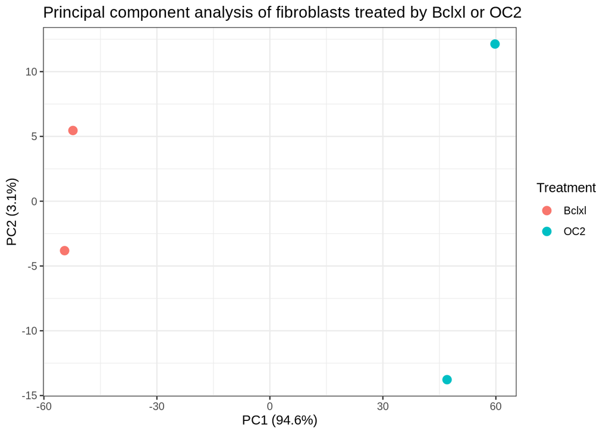

Figure 4: PCA analysis of fibroblasts treated with Bclxl (control) and OC2.

```r
#Sticking the metadata-results onto the PCA results
PCA_plotting<-cbind(metadata, PCA$x)

#Creating variables containing the exact PC proportion of variance percentages
PC1<-round(PCA_summary["Proportion of Variance","PC1"]*100, digits=1)
PC2<-round(PCA_summary["Proportion of Variance","PC2"]*100, digits=1)

#Creating a plot
PCA_plotting %>% ggplot(aes(x=PC1, y=PC2))+
  geom_point(aes(colour=Treatment), size=3)+
  labs(
    title="Principal component analysis of fibroblasts treated by Bclxl or OC2",
    x=paste0("PC1 (",PC1,"%)"),
    y=paste0("PC2 (",PC2,"%)")
  )+
  theme_bw()
```

Remarkable of these graphs is that the proportion of variance of the first principal component, PC1, is equal to 94,6% of the total variance. This is a exceptional large amount, and based on figure 4, this PC splits cells treat with Bclxl and cells treated with OC2. Based on this, we can reasonably conclude that treatment with OC2 is associated with different gene expressions than treatment with Bclxl.

To further study whether the genes affected by this are upregulated or downregulated, a DGE analysis will be performed. Based on this DGE analysis, a volcano plot and a heatmap will be created to showcase the total amount of up/downregulated genes and the top 5 of both up- and downregulated genes.

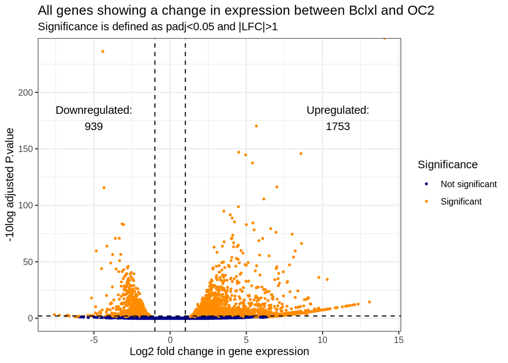

```r
#Performing DGE analysis
neuron_dge<-DESeq(dds)

#Storing the results with proper p and LFC value in a seperate RDS and inspecting the results
neuron_dge_results<-results(neuron_dge, alpha = 0.01, lfcThreshold = 1)

#Filtering all NA padj values
neuron_dge_plotting<-neuron_dge_results %>% data.frame() %>% filter(!is.na(padj))

#Adding a variable which tracks if a gene has a padj<0.05 and a log>|1|
neuron_dge_plotting<-neuron_dge_plotting %>% mutate(
  Significance=if_else(padj<0.05 & abs(log2FoldChange)>1,"Significant","Not significant")
)

#seperating the total amount of up- and downregulated genes
upregulated<-neuron_dge_results %>% as.data.frame() %>% filter(padj<0.01 & log2FoldChange>1) %>% nrow()
downregulated<-neuron_dge_results %>% as.data.frame() %>% filter(padj<0.01 & log2FoldChange< -1) %>% nrow()

#Plotting it in graph
neuron_dge_plotting %>% ggplot(aes(x=log2FoldChange, y=-log10(padj)))+
  geom_point(aes(colour=Significance), size=0.7)+
  labs(
    title = "All genes showing a change in expression between Bclxl and OC2",
    subtitle = "Significance is defined as padj<0.05 and |LFC|>1",
    x="Log2 fold change in gene expression",
    y="-10log adjusted P.value"
  )+
  geom_vline(xintercept = 1, linetype="dashed")+
  geom_vline(xintercept = -1, linetype="dashed")+
  geom_hline(yintercept = -log10(0.01), linetype="dashed")+
  scale_colour_manual(values=c("Dark blue", "Dark orange"))+
  annotate("text", x=-5, y=170, label=c("Downregulated:\n\n",downregulated))+
  annotate("text", x=11, y=170, label=c("Upregulated:\n\n",upregulated))+
  theme_bw()
```

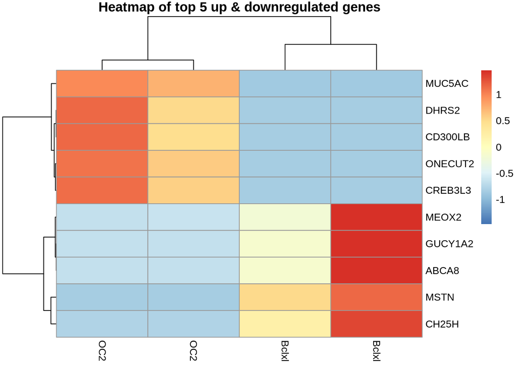

Figure 6: Heatmap showing the relative expression of the top 5 upregulated and downregulated genes.

```r
#Obtaining the top 5 upregulated/downregulated genes, putting them into 1 list
neuron_dge_results_p_0.01<-neuron_dge_results %>% as.data.frame() %>% filter(padj<0.01)

bot_5_genes<-rownames(neuron_dge_results_p_0.01[order(neuron_dge_results_p_0.01$log2FoldChange)[1:5],])
top_5_genes<-rownames(neuron_dge_results_p_0.01[order(neuron_dge_results_p_0.01$log2FoldChange, decreasing = TRUE)[1:5],])
tb_10_genes<-c(top_5_genes, bot_5_genes)

#Obtaining the original data associated with these genes
count_values<-assay(dds)[tb_10_genes,]

#Replacing column names with treament
colnames(count_values)<-colData(dds)$Treatment

#Replacing row name entrez numbers with gene names
tb_10_genes_geneID<-data.frame(entrez=tb_10_genes)
tb_10_genes_geneID$Symbol<-mapIds(org.Hs.eg.db,
       keys=tb_10_genes_geneID$entrez,
       column = "SYMBOL",
       keytype = "ENTREZID",
       multiVals = "first")
rownames(count_values)<-tb_10_genes_geneID$Symbol

#Generating a heatmap
pheatmap(count_values, scale="row", main = "Heatmap of top 5 up & downregulated genes")
```

In this heatmap we can see a multitude of genes, from MUC5AC to CH25H, are up/downregulated by exposure too Bclxl/OC2. However, next to information about specific genes, we also want a bigger picture of what kind of biological processes *all* up/downregulated genes encode for. For this, we have performed an GO-enrichment analysis, as seen bellow.

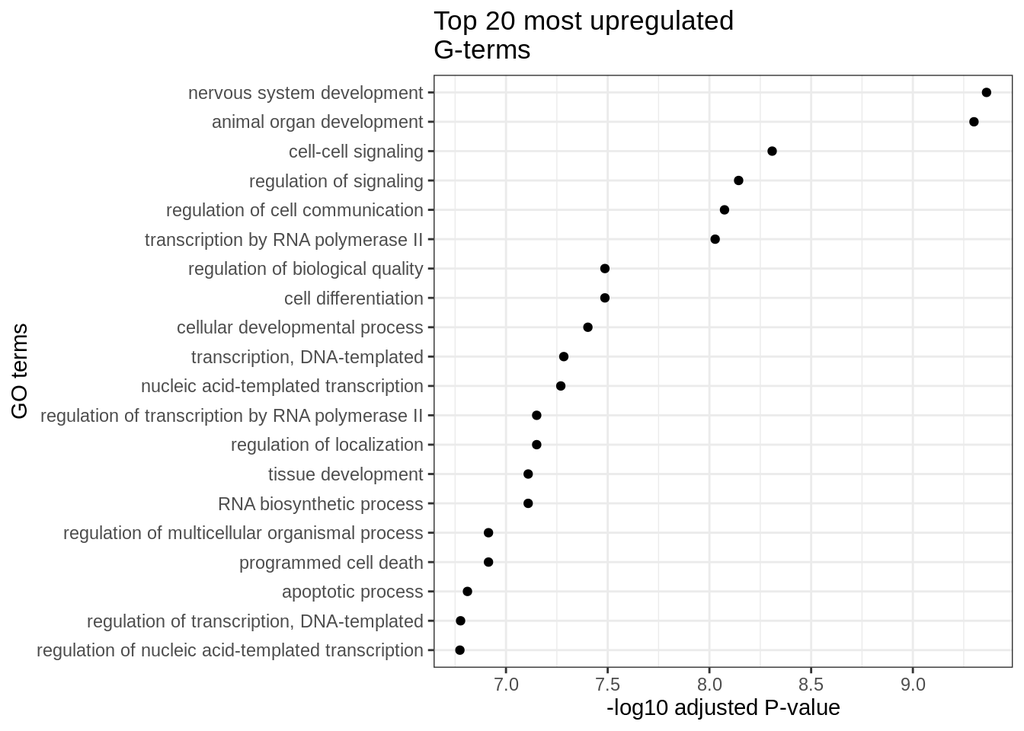

Figure 7: Top 20 GO-terms associated with gene upregulation in OC2 treated cells, in comparisson to Bclxl treated cells

```r
#Selecteren van upregulated, downregulated and all genes
neuron_dge_upregulated<-neuron_dge_results %>% data.frame() %>% filter(log2FoldChange>1 & padj<0.01) %>% rownames()
neuron_dge_downregulated<-neuron_dge_results %>% data.frame() %>% filter(log2FoldChange< -1 & padj<0.01) %>% rownames()
neuron_dge_all<-neuron_dge_results %>% data.frame() %>% rownames()

# ^ UPREGULATED ####
#GO-term analysis object creation
test_object<-new("GOHyperGParams",
    geneIds=neuron_dge_upregulated,
    universeGeneIds=neuron_dge_all,
    annotation="org.Hs.eg.db",
    ontology="BP",
    pvalueCutoff=1,
    testDirection="over")

#Hyper G test
neuron_dge_hyperG<-hyperGTest(test_object)
neuron_dge_hyperG_result<-summary(neuron_dge_hyperG)

#Padjust for the "BH" method, Bejmani hochberg which compensates for the false discovery rate
neuron_dge_hyperG_result$padj<-p.adjust(neuron_dge_hyperG_result$Pvalue, method="BH")

#Selecting gene sets larger than 5 but smaller than 500, to prevent too generic/too specific results from influencing the results
neuron_dge_hyperG_result<-neuron_dge_hyperG_result %>% filter(Count>5 & Count<500)

#Selecting the top 20 GO-terms, to prevent the graph from become unreadable
hyperG_top20<-neuron_dge_hyperG_result[order(neuron_dge_hyperG_result$padj)[1:20],]

#Creating a factor so that the graph goes the proper way
hyperG_top20$Term<-factor(hyperG_top20$Term,
                          levels = hyperG_top20$Term[
                            order(hyperG_top20$padj,decreasing = TRUE)
                          ])

#Plotting the p-values of the top 20
hyperG_top20 %>% ggplot(aes(x=Term, y=-log10(padj)))+
  geom_point()+
  coord_flip()+
  labs(
    title="Top 20 most upregulated \nG-terms",
    x="GO terms",
    y="-log10 adjusted P-value"
  )+
  theme_bw()
```

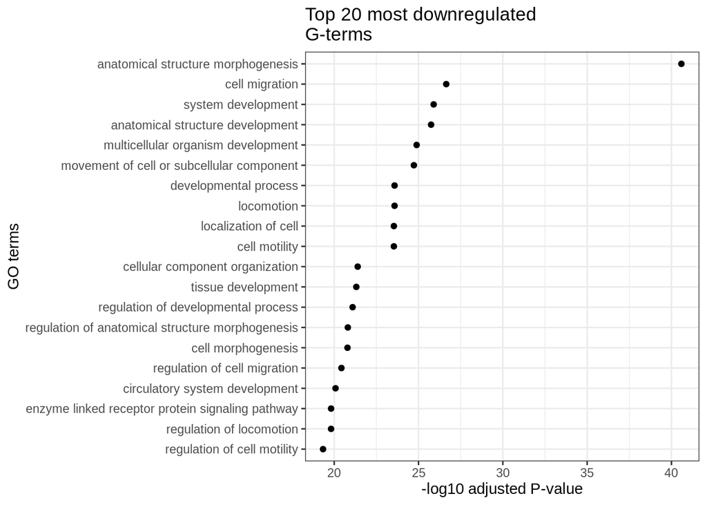

Figure 8: Top 20 GO-terms associated with gene downregulation in OC2 treated cells, in comparisson to Bclxl treated cells

```r
test_object_down<-new("GOHyperGParams",
                 geneIds=neuron_dge_downregulated,
                 universeGeneIds=neuron_dge_all,
                 annotation="org.Hs.eg.db",
                 ontology="BP",
                 pvalueCutoff=1,
                 testDirection="over")

#Hyper G test
neuron_dge_hyperG_down<-hyperGTest(test_object_down)
neuron_dge_hyperG_result_down<-summary(neuron_dge_hyperG_down)

#Padjust for the "BH" method, Bejmani hochberg which compensates for the false discovery rate
neuron_dge_hyperG_result_down$padj<-p.adjust(neuron_dge_hyperG_result_down$Pvalue, method="BH")

#Selecting gene sets larger than 5 but smaller than 500, to prevent too generic/too specific results from influencing the results
neuron_dge_hyperG_result_down<-neuron_dge_hyperG_result_down %>% filter(Count>5 & Count<500)

#Selecting the top 20 GO-terms, to prevent the graph from become unreadable
hyperG_top20_down<-neuron_dge_hyperG_result_down[order(neuron_dge_hyperG_result_down$padj)[1:20],]

#Making a factor so the plot goes in the proper direction
hyperG_top20_down$Term <- factor(hyperG_top20_down$Term,
                                 levels = hyperG_top20_down$Term[
                                   order(hyperG_top20_down$padj, decreasing = TRUE)
                                 ])

#Plotting the p-values of the top 20
hyperG_top20_down %>% ggplot(aes(x=Term, y=-log10(padj)))+
  geom_point()+
  coord_flip()+
  labs(
    title="Top 20 most downregulated \nG-terms",
    x="GO terms",
    y="-log10 adjusted P-value"
  )+
  theme_bw()
```

In figure 7, we can see that off all G-terms, “nervous system development” is the most upregulated term. This corresponds to our hypothesis, in which we hypothesized that exposure to OC2 would stimulate fibroblasts transforming into neuronal cells. Furthermore, in figure 8, we can see that the most downregulated G-term is “anatomical structure morphogenesis” -log10 P-value of almost 1.5 times the size of the next G-term. A decrease in anatomical structure morphogenesis could be explained by the fact that fibroblasts, being skin cells, have a large dependancy on anatomical structures, while neuronal cells have a less defined structure.

Based on the results from the GO enrichment analysis’, we can conclude that in comparison to fibroblasts exposed to Bclxl, fibroblasts exposed to ONECUT2 do show signs of increased transformation into neuronal cells.

Finally, a function has been set up so that with the input of a GO:term, the associated gene symbols can be aquired:

```r
#Making the function
GOidToSymbol<-function(GOid){
  if(str_detect(string = paste(GOid), pattern = "GO:[0-9]{7}$")){
    GO_list<-select(org.Hs.eg.db,
                    keys=GOid,
                    columns = "SYMBOL",
                    keytype = "GO",
                    multiVals = "list")
    GO_list$SYMBOL %>% as.vector()
  }
  else("Input GO-term is not of the correct type: has to start 'GO:' followed by 7 numbers")
}

#Running function
GOidToSymbol(GOid = c("GO:0036003"))
```

```
## [1] "ATF4"   "MUC1"   "NFE2L2" "MAPK7"  "TP53"   "KLF2"   "GCN1"
```

```r
#Is the output a vector?
GOidToSymbol(GOid = c("GO:0036003")) %>% is.vector()
```

```
## [1] TRUE
```

```r
#Is the output a character?
GOidToSymbol(GOid = c("GO:0036003")) %>% is.character()
```

```
## [1] TRUE
```

```r
#Does the command give a proper response if the input is too long/short/spelled wrong?
GOidToSymbol(GOid = c("GO:003603303")) #Too long
```

```
## [1] "Input GO-term is not of the correct type: has to start 'GO:' followed by 7 numbers"
```

```r
GOidToSymbol(GOid = c("GO:0033")) #Too short
```

```
## [1] "Input GO-term is not of the correct type: has to start 'GO:' followed by 7 numbers"
```

```r
GOidToSymbol(GOid = c("GD:0036003")) #GO spelled wrong
```

```
## [1] "Input GO-term is not of the correct type: has to start 'GO:' followed by 7 numbers"
```